# Homework 11 — Completed

## Question 1: Implementing K-means

I use **seed 1108** for reproducibility. The implementation below uses only basic R operations; it does not call `kmeans()`.

```r
set.seed(1108)
x <- matrix(rnorm(20), nrow = 10, ncol = 2)
colnames(x) <- c("x1", "x2")

# Draw a random assignment with all K clusters represented.
random_nonempty <- function(n, K) {
  stopifnot(K >= 1L, K <= n)
  sample(c(seq_len(K), sample.int(K, n - K, replace = TRUE)))
}

# Squared Euclidean distances, one row per observation and column per center.
squared_distances <- function(X, centers) {
  outer(rowSums(X^2), rowSums(centers^2), "+") -
    2 * X %*% t(centers)
}

# Means of nonempty clusters; an empty cluster retains its previous mean.
update_centers <- function(X, assignment, K, previous = NULL) {
  centers <- if (is.null(previous)) {
    matrix(NA_real_, K, ncol(X))
  } else {
    previous
  }
  for (k in seq_len(K)) {
    members <- which(assignment == k)
    if (length(members) > 0L) {
      centers[k, ] <- colMeans(X[members, , drop = FALSE])
    }
  }
  rownames(centers) <- paste0("Cluster ", seq_len(K))
  colnames(centers) <- colnames(X)
  centers
}

initial <- random_nonempty(nrow(x), 2)
means_before <- update_centers(x, initial, 2)
updated <- max.col(-squared_distances(x, means_before), ties.method = "first")
cat("Initial assignments:", initial, "\n")
```

```
Initial assignments: 1 1 2 1 2 1 1 1 1 1
```

```r
cat("Means used for the reassignment:\n")
```

```
Means used for the reassignment:
```

```r
print(round(means_before, 4))
```

```
              x1      x2
Cluster 1 0.8272  0.1122
Cluster 2 1.2730 -0.1154
```

```r
cat("Updated assignments:", updated, "\n")
```

```
Updated assignments: 1 2 1 2 2 1 1 2 1 1
```

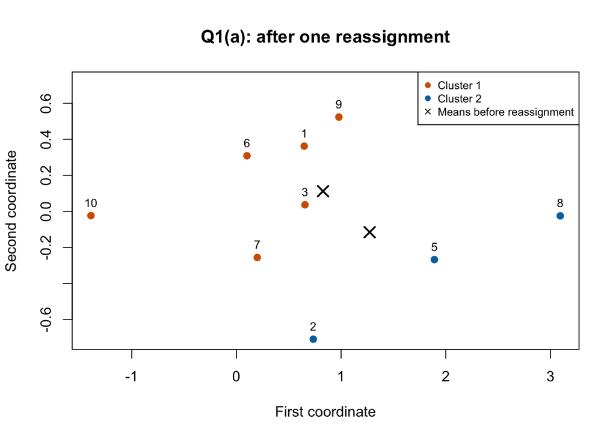

```r
plot(x, col = c("#D55E00", "#0072B2")[updated], pch = 19,
     xlab = "First coordinate", ylab = "Second coordinate",
     main = "Q1(a): after one reassignment")
text(x, labels = seq_len(nrow(x)), pos = 3, cex = 0.8)
points(means_before, pch = 4, cex = 1.6, lwd = 2)
legend("topright", c("Cluster 1", "Cluster 2", "Means before reassignment"),
       col = c("#D55E00", "#0072B2", "black"), pch = c(19, 19, 4), cex = 0.75)
```

### (b) General K-means function

The function handles any numeric matrix and any `K` from 1 to the number of observations. If a cluster becomes empty, its previous center is retained. Once the assignment loop stops, centers are recalculated from the final memberships before computing the objective. A maximum iteration limit prevents infinite iteration.

```r
my_kmeans <- function(X, K, max_iter = 100L, initial_assignment = NULL) {
  X <- as.matrix(X)
  storage.mode(X) <- "double"
  if (!is.numeric(X) || any(!is.finite(X)))
    stop("X must contain finite numeric values")
  n <- nrow(X)
  if (length(K) != 1 || K != as.integer(K) || K < 1 || K > n)
    stop("K must be an integer between 1 and nrow(X)")
  if (length(max_iter) != 1 || max_iter < 1 || max_iter != as.integer(max_iter))
    stop("max_iter must be a positive integer")
  if (is.null(initial_assignment))
    initial_assignment <- random_nonempty(n, K)
  if (length(initial_assignment) != n || anyNA(initial_assignment) ||
      any(!initial_assignment %in% seq_len(K)) ||
      any(tabulate(initial_assignment, nbins = K) == 0L))
    stop("Initial assignment must assign every observation and use every cluster")

  assignment <- as.integer(initial_assignment)
  centers <- update_centers(X, assignment, K)
  converged <- FALSE
  for (iter in seq_len(max_iter)) {
    centers <- update_centers(X, assignment, K, centers)
    next_assignment <- max.col(-squared_distances(X, centers), ties.method = "first")
    if (identical(next_assignment, assignment)) {
      converged <- TRUE
      break
    }
    assignment <- next_assignment
  }
  centers <- update_centers(X, assignment, K, centers)
  d2 <- squared_distances(X, centers)
  wcss <- sum(pmax(0, d2[cbind(seq_len(n), assignment)]))
  list(cluster = assignment, centers = centers, tot.withinss = wcss,
       iterations = iter, converged = converged)
}
```

### (c) Two different initial assignments

```r
set.seed(1109)
init1 <- random_nonempty(10, 2)
init2 <- random_nonempty(10, 2)
while (identical(init1, init2)) init2 <- random_nonempty(10, 2)
fit1 <- my_kmeans(x, 2, initial_assignment = init1)
fit2 <- my_kmeans(x, 2, initial_assignment = init2)
for (j in 1:2) {
  f <- list(fit1, fit2)[[j]]
  cat("Run", j, "initial assignments:", list(init1, init2)[[j]], "\n")
  cat("Final assignments:", f$cluster, "\n")
  print(round(f$centers, 4))
  cat("Within-cluster sum of squares:", round(f$tot.withinss, 5), "\n")
  cat("Iterations:", f$iterations, "; converged:", f$converged, "\n\n")
}
```

```
Run 1 initial assignments: 2 1 1 1 1 2 2 2 1 1
Final assignments: 1 1 1 2 2 1 1 2 1 1
              x1     x2
Cluster 1 0.2749 0.0347
Cluster 2 2.4132 0.1414
Within-cluster sum of squares: 6.14561
Iterations: 3 ; converged: TRUE

Run 2 initial assignments: 2 1 1 1 2 1 1 2 1 2
Final assignments: 1 1 1 2 2 1 1 2 1 1
              x1     x2
Cluster 1 0.2749 0.0347
Cluster 2 2.4132 0.1414
Within-cluster sum of squares: 6.14561
Iterations: 3 ; converged: TRUE
```

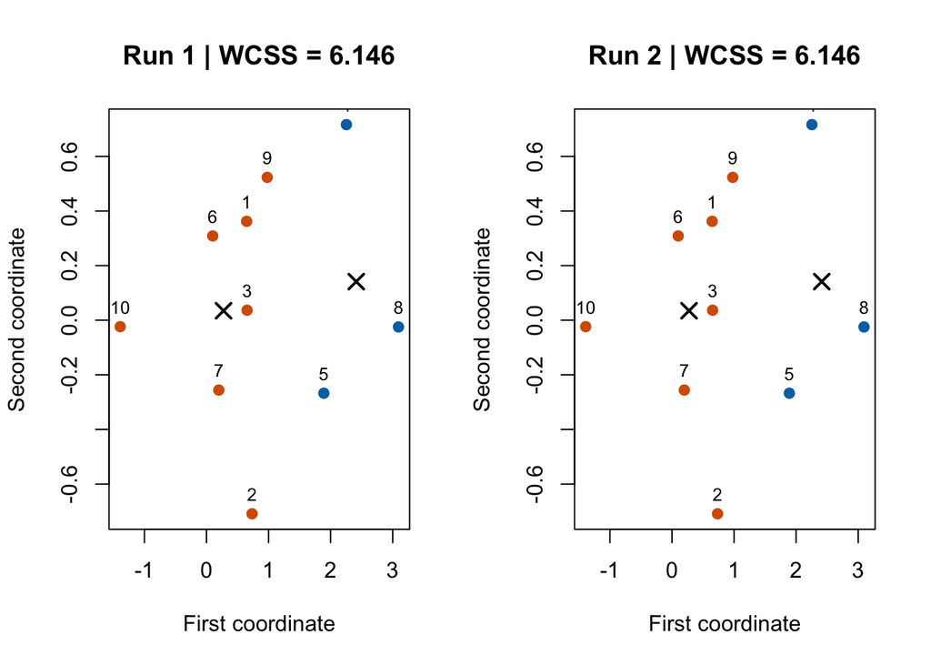

```r
oldpar <- par(mfrow = c(1, 2))
for (j in 1:2) {
  f <- list(fit1, fit2)[[j]]
  plot(x, col = c("#D55E00", "#0072B2")[f$cluster], pch = 19,
       xlab = "First coordinate", ylab = "Second coordinate",
       main = paste("Run", j, "| WCSS =", round(f$tot.withinss, 3)))
  text(x, labels = 1:10, pos = 3, cex = 0.8)
  points(f$centers, pch = 4, lwd = 2, cex = 1.5)
}
```

```r
par(oldpar)
# Cluster labels may be exchanged; compare pairwise co-membership instead.
same_grouping <- identical(outer(fit1$cluster, fit1$cluster, "=="),
                           outer(fit2$cluster, fit2$cluster, "=="))
same_wcss <- isTRUE(all.equal(fit1$tot.withinss, fit2$tot.withinss,
                              tolerance = 1e-8))
cat("Same grouping (ignoring label swaps)?", same_grouping, "\n")
```

```
Same grouping (ignoring label swaps)? TRUE
```

```r
cat("Same objective value?", same_wcss, "\n")
```

```
Same objective value? TRUE
```

The two runs produce the same grouping (up to a swap of cluster labels) and have the same within-cluster sum of squares. K-means is sensitive to initialization because its iterative updates minimize the objective locally rather than guaranteeing the global minimum. A different grouping and objective can result when the starting assignments lead to different local optima; agreement in this example does not imply that all initializations would agree.

## Question 2: Image color compression

### (a) Original image and pixel matrix

For a reproducible color image with no external download, I use a **procedurally drawn sunset landscape**. Its red, green, and blue channels are generated directly below. The image is 160 pixels wide and 120 pixels high, below the 200-by-200 limit. Pixel values are on the 0-to-1 RGB scale throughout.

```r
height <- 120L
width <- 160L
img <- array(0, dim = c(height, width, 3L))
for (i in seq_len(height)) {
  for (j in seq_len(width)) {
    u <- (j - 1) / (width - 1)
    v <- (i - 1) / (height - 1)
    sun <- exp(-((u - 0.72)^2 + (v - 0.43)^2) / 0.012)
    if (v < 0.68) {
      rgb <- c(0.18 + 0.70*v, 0.20 + 0.28*v, 0.52 - 0.40*v) +
        sun * c(0.30, 0.35, 0.18)
    } else {
      ripple <- 0.06 * sin(85*v + 32*u)
      rgb <- c(0.12 + ripple, 0.24 + ripple, 0.35 + ripple) +
        sun * c(0.24, 0.18, 0.05)
    }
    if (v > 0.56 + 0.10*sin(10*u) + 0.05*cos(21*u) && v < 0.76)
      rgb <- c(0.12, 0.20, 0.24)
    img[i, j, ] <- pmin(1, pmax(0, rgb))
  }
}
pixels <- matrix(img, ncol = 3)
colnames(pixels) <- c("Red", "Green", "Blue")
cat("Image dimensions (height x width x RGB):", paste(dim(img), collapse = " x "), "\n")
```

```
Image dimensions (height x width x RGB): 120 x 160 x 3
```

```r
cat("Pixel data dimensions:", paste(dim(pixels), collapse = " x "), "\n")
```

```
Pixel data dimensions: 19200 x 3
```

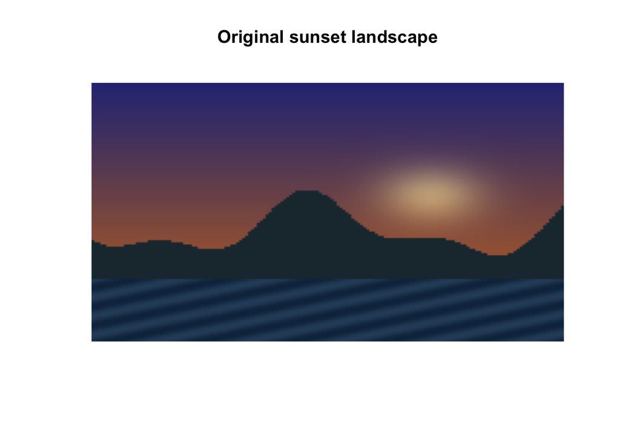

```r
plot.new()
rasterImage(as.raster(img), 0, 0, 1, 1)
title("Original sunset landscape")
```

### (b) K-means compression at four K values

Each fit starts from a nonempty random assignment. Every reconstructed pixel receives the RGB mean of its assigned cluster. All plots use the same RGB scale, [0, 1].

```r
set.seed(1110)
K_values <- c(2L, 3L, 5L, 10L)
fits <- lapply(K_values, function(k) my_kmeans(pixels, K = k, max_iter = 50L))
names(fits) <- paste0("K=", K_values)
for (j in seq_along(K_values)) {
  cat("\nK =", K_values[j], "\n")
  cat("RGB cluster means (0 to 1):\n")
  print(round(fits[[j]]$centers, 4))
  cat("Within-cluster sum of squares:", round(fits[[j]]$tot.withinss, 4), "\n")
  cat("Converged:", fits[[j]]$converged, "\n")
}
```

```
K = 2
RGB cluster means (0 to 1):
             Red  Green   Blue
Cluster 1 0.4994 0.3517 0.3741
Cluster 2 0.1692 0.2261 0.3642
Within-cluster sum of squares: 342.1188
Converged: TRUE

K = 3
RGB cluster means (0 to 1):
             Red  Green   Blue
Cluster 1 0.1092 0.2086 0.2826
Cluster 2 0.5379 0.3737 0.3621
Cluster 3 0.2665 0.2532 0.4481
Within-cluster sum of squares: 171.8328
Converged: TRUE

K = 5
RGB cluster means (0 to 1):
             Red  Green   Blue
Cluster 1 0.4194 0.3010 0.3912
Cluster 2 0.2563 0.2306 0.4766
Cluster 3 0.5977 0.4147 0.3541
Cluster 4 0.1531 0.2731 0.3831
Cluster 5 0.1041 0.1989 0.2648
Within-cluster sum of squares: 89.6415
Converged: TRUE

K = 10
RGB cluster means (0 to 1):
              Red  Green   Blue
Cluster 1  0.1531 0.2731 0.3831
Cluster 2  0.6787 0.5459 0.4587
Cluster 3  0.2859 0.2708 0.3643
Cluster 4  0.1041 0.1989 0.2648
Cluster 5  0.2843 0.2707 0.3663
Cluster 6  0.5726 0.3723 0.3189
Cluster 7  0.3319 0.2619 0.4349
Cluster 8  0.2833 0.2685 0.3673
Cluster 9  0.2271 0.2188 0.4931
Cluster 10 0.4480 0.3157 0.3799
Within-cluster sum of squares: 42.7102
Converged: TRUE
```

[figure not shown]

```r
oldpar <- par(mfrow = c(2, 2), mar = c(2, 2, 3, 1))
for (j in seq_along(K_values)) {
  f <- fits[[j]]
  compressed <- array(f$centers[f$cluster, ], dim = dim(img))
  plot.new()
  rasterImage(as.raster(pmin(1, pmax(0, compressed))), 0, 0, 1, 1)
  title(paste0("K = ", K_values[j], " | WCSS = ", round(f$tot.withinss, 1)))
}
```

```r
par(oldpar)
```

```r
comparison <- data.frame(K = K_values,
                         WCSS = vapply(fits, function(z) z$tot.withinss, numeric(1)))
comparison$Improvement_from_previous <- c(NA, -diff(comparison$WCSS))
print(comparison, row.names = FALSE, digits = 5)
```

```
  K    WCSS Improvement_from_previous
  2 342.119                        NA
  3 171.833                   170.286
  5  89.641                    82.191
 10  42.710                    46.931
```

## Question 3: Hierarchical clustering of cars

### (a) Standardization and dendrograms

```r
file <- if (file.exists("data/mtcars.csv")) "data/mtcars.csv" else "mtcars.csv"
if (!file.exists(file)) stop("Place mtcars.csv beside this QMD or at data/mtcars.csv")
cars <- read.csv(file, stringsAsFactors = FALSE, check.names = FALSE)
stopifnot("car" %in% names(cars), nrow(cars) == 32L)
rownames(cars) <- cars$car
numeric_cars <- cars[, setdiff(names(cars), "car"), drop = FALSE]
stopifnot(all(vapply(numeric_cars, is.numeric, logical(1))))
scaled_cars <- scale(numeric_cars)
cat("Column means after scaling:\n")
```

```
Column means after scaling:
```

```r
print(round(colMeans(scaled_cars), 5))
```

```
 mpg  cyl disp   hp drat   wt qsec   vs   am gear carb
   0    0    0    0    0    0    0    0    0    0    0
```

```r
cat("Column standard deviations after scaling:\n")
```

```
Column standard deviations after scaling:
```

```r
print(round(apply(scaled_cars, 2, sd), 5))
```

```
 mpg  cyl disp   hp drat   wt qsec   vs   am gear carb
   1    1    1    1    1    1    1    1    1    1    1
```

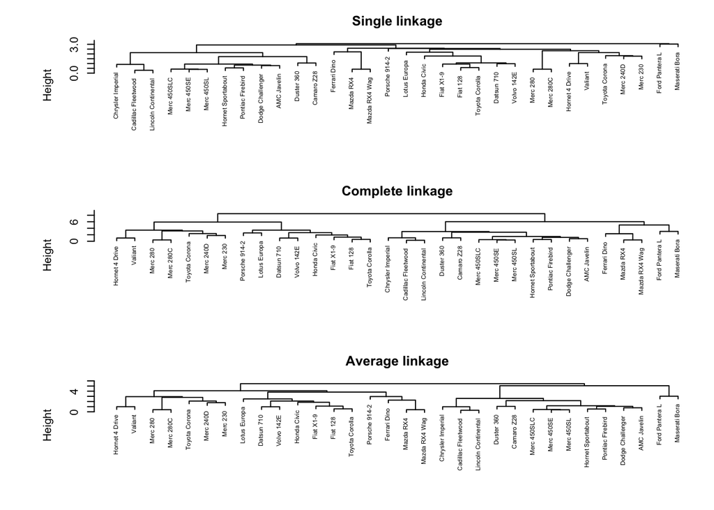

```r
d <- dist(scaled_cars, method = "euclidean")
hc_single <- hclust(d, method = "single")
hc_complete <- hclust(d, method = "complete")
hc_average <- hclust(d, method = "average")
oldpar <- par(mfrow = c(3, 1), mar = c(3, 7, 3, 1))
plot(hc_single, main = "Single linkage", xlab = "", sub = "", cex = 0.55)
plot(hc_complete, main = "Complete linkage", xlab = "", sub = "", cex = 0.55)
plot(hc_average, main = "Average linkage", xlab = "", sub = "", cex = 0.55)
```

```r
par(oldpar)
```

**Comparison:** Single linkage uses the smallest distance between clusters and tends to create chaining: cars can join a large group one at a time through close neighbors. Complete linkage uses the largest pairwise distance and therefore favors compact groups, often showing more distinct separations in its dendrogram. Average linkage considers the average distance across all pairs of cars in two clusters, providing an intermediate result. The exact merge order and heights vary across these three definitions, although especially similar cars may group together across methods.

### (b) Cluster choice, memberships, and original-scale means

I choose **complete linkage with three clusters**, favoring compact, interpretable groups and a manageable number of profiles. The horizontal cut is displayed on the dendrogram, and the original-scale means are computed from the unstandardized data.

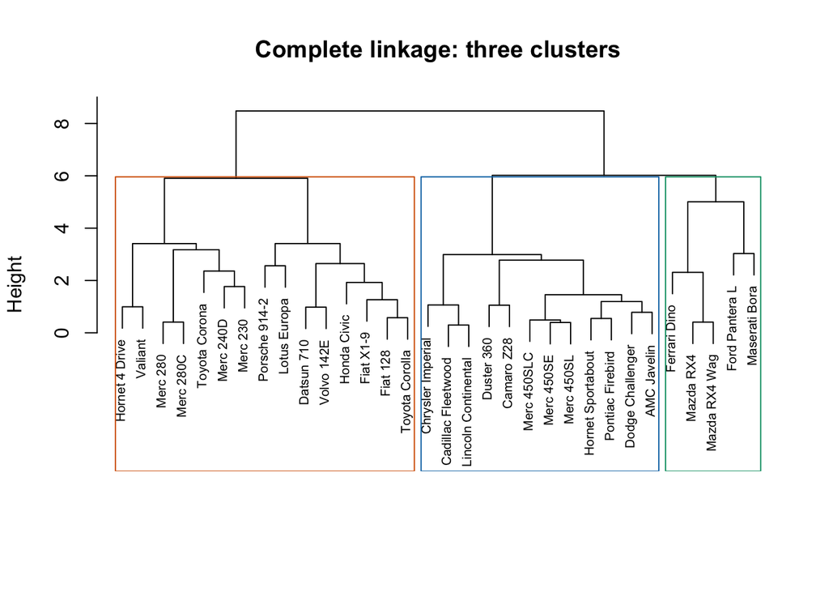

```r
chosen_K <- 3L
membership <- cutree(hc_complete, k = chosen_K)
plot(hc_complete, main = "Complete linkage: three clusters",
     xlab = "", sub = "", cex = 0.65)
rect.hclust(hc_complete, k = chosen_K, border = c("#D55E00", "#0072B2", "#009E73"))
```

```r
cat("Cluster memberships:\n")
```

```
Cluster memberships:
```

```r
for (k in seq_len(chosen_K)) {
  cat("\nCluster", k, "(n =", sum(membership == k), "):\n")
  cat(paste(names(membership)[membership == k], collapse = ", "), "\n")
}
```

```
Cluster 1 (n = 5 ):
Mazda RX4, Mazda RX4 Wag, Ford Pantera L, Ferrari Dino, Maserati Bora

Cluster 2 (n = 15 ):
Datsun 710, Hornet 4 Drive, Valiant, Merc 240D, Merc 230, Merc 280, Merc 280C, Fiat 128, Honda Civic, Toyota Corolla, Toyota Corona, Fiat X1-9, Porsche 914-2, Lotus Europa, Volvo 142E

Cluster 3 (n = 12 ):
Hornet Sportabout, Duster 360, Merc 450SE, Merc 450SL, Merc 450SLC, Cadillac Fleetwood, Lincoln Continental, Chrysler Imperial, Dodge Challenger, AMC Javelin, Camaro Z28, Pontiac Firebird
```

```r
cluster_means <- aggregate(numeric_cars,
                           by = list(Cluster = membership), FUN = mean)
cluster_means <- cluster_means[order(cluster_means$Cluster), ]
cat("\nCluster means on original scales:\n")
```

```
Cluster means on original scales:
```

```r
print(cluster_means, row.names = FALSE, digits = 4)
```

```
 Cluster   mpg   cyl  disp     hp  drat    wt  qsec     vs     am  gear  carb
       1 18.50 6.800 223.4 198.80 3.836 3.001 15.62 0.0000 1.0000 4.600 5.200
       2 24.65 4.533 131.6  91.33 3.897 2.580 19.16 0.9333 0.5333 3.933 1.800
       3 15.05 8.000 357.6 194.17 3.121 4.104 17.14 0.0000 0.0000 3.000 3.083
```

To interpret the groups, compare their average fuel economy (`mpg`), engine size (`disp`), horsepower (`hp`), and weight (`wt`), while also checking cylinder count (`cyl`) and transmission (`am`). The following table orders the groups by their average MPG and gives a concise data-driven profile.

```r
profile <- cluster_means[order(-cluster_means$mpg),
                         c("Cluster", "mpg", "cyl", "disp", "hp", "wt", "am")]
profile$Fuel_economy_rank <- c("Highest MPG", "Middle MPG", "Lowest MPG")
print(profile, row.names = FALSE, digits = 4)
```

```
 Cluster   mpg   cyl  disp     hp    wt     am Fuel_economy_rank
       2 24.65 4.533 131.6  91.33 2.580 0.5333       Highest MPG
       1 18.50 6.800 223.4 198.80 3.001 1.0000        Middle MPG
       3 15.05 8.000 357.6 194.17 4.104 0.0000        Lowest MPG
```

The cluster with the highest average MPG is cluster **2**, with mean MPG **24.65**, mean horsepower **91.3**, and mean weight **2.58** (in thousands of pounds). The lowest-MPG cluster is **3**, with mean MPG **15.05**, mean horsepower **194.2**, and mean weight **4.1**. Cluster **1** is intermediate in fuel economy; the complete table shows how its engine and performance characteristics compare. The dendrogram supports treating these as separate groups under complete linkage, although three clusters is an interpretive choice rather than a uniquely correct answer.

**Why standardize?** The variables have very different units and numerical ranges. Without scaling, `disp` and `hp` could dominate Euclidean distances simply because their numerical values are much larger than those of `am`, `vs`, or `wt`. Standardization puts each variable on a comparable standard-deviation scale, so no variable dominates merely due to its measurement units. It does not, however, eliminate correlations between variables.